# Intro to DS - KNN Classifiers: PIMA dataset

GWU Intro to Data Science DATS 6101

2022-11-17

# HW Assignment - KNN

This exercise uses the Pima.te and Pima.tr dataset from the MASS package, which includes measurement on a population of women of Pima Indian heritage living near Phoenix, Arizona. The women were tested for diabetes according to World Health Organization criteria. We are interested in predicting diabetes status as a function of the other variables.

The variables in the dataset are:

- `npreg` : number of pregnancies.
- `glu` : plasma glucose concentration
- `bp` : diastolic blood pressure (mm Hg) skin triceps skinfold thickness (mm)
- `bmi` : body mass index
- `ped` : diabetes pedigree function
- `age` : age in years
- `type` : Yes or No: diabetic by WHO criteria

## Pima Dataset

### Question 1

**Obtain the dataset**  
In the `MASS` library, combine the two datasets `Pima.te` and `Pima.tr` back into one complete dataset, call it `pima`. (Try function `rbind()`.) How many observations are there?

```r
pima <- rbind(Pima.te, Pima.tr)
nrow(pima)
```

[output not shown]

There are 532 observations.

### Question 2

**Summary**  
Obtain some basic summary statistics for the full dataset `pima`.

```r
str(pima)
```

```
## 'data.frame':    532 obs. of  8 variables:
##  $ npreg: int  6 1 1 3 2 5 0 1 3 9 ...
##  $ glu  : int  148 85 89 78 197 166 118 103 126 119 ...
##  $ bp   : int  72 66 66 50 70 72 84 30 88 80 ...
##  $ skin : int  35 29 23 32 45 19 47 38 41 35 ...
##  $ bmi  : num  33.6 26.6 28.1 31 30.5 25.8 45.8 43.3 39.3 29 ...
##  $ ped  : num  0.627 0.351 0.167 0.248 0.158 0.587 0.551 0.183 0.704 0.263 ...
##  $ age  : int  50 31 21 26 53 51 31 33 27 29 ...
##  $ type : Factor w/ 2 levels "No","Yes": 2 1 1 2 2 2 2 1 1 2 ...
```

```r
summary(pima)
```

```
##      npreg            glu              bp             skin           bmi
##  Min.   : 0.00   Min.   : 56.0   Min.   : 24.0   Min.   : 7.0   Min.   :18.2
##  1st Qu.: 1.00   1st Qu.: 98.8   1st Qu.: 64.0   1st Qu.:22.0   1st Qu.:27.9
##  Median : 2.00   Median :115.0   Median : 72.0   Median :29.0   Median :32.8
##  Mean   : 3.52   Mean   :121.0   Mean   : 71.5   Mean   :29.2   Mean   :32.9
##  3rd Qu.: 5.00   3rd Qu.:141.2   3rd Qu.: 80.0   3rd Qu.:36.0   3rd Qu.:36.9
##  Max.   :17.00   Max.   :199.0   Max.   :110.0   Max.   :99.0   Max.   :67.1
##       ped             age        type
##  Min.   :0.085   Min.   :21.0   No :355
##  1st Qu.:0.259   1st Qu.:23.0   Yes:177
##  Median :0.416   Median :28.0
##  Mean   :0.503   Mean   :31.6
##  3rd Qu.:0.658   3rd Qu.:38.0
##  Max.   :2.420   Max.   :81.0
```

### Question 3

**Pairs**  
Another quick EDA to perform, you can plot the `pairs()`. The plot function can handle both numerical and categorical variable type. After trying the function in the R base library, also try the modified version with `pairs.panels()`. Comment on interesting relationships.

```r
## Example of pairs.panel on the iris data set -- edit for your analysis of the pima data ##
loadPkg("psych")
pairs.panels(iris[,-5],
             method = "pearson", # correlation method
             hist.col = "#00AFBB", # set histogram color, can use "#22AFBB", "red",
             density = TRUE,  # show density plots
             ellipses = TRUE # show correlation ellipses
             )
```

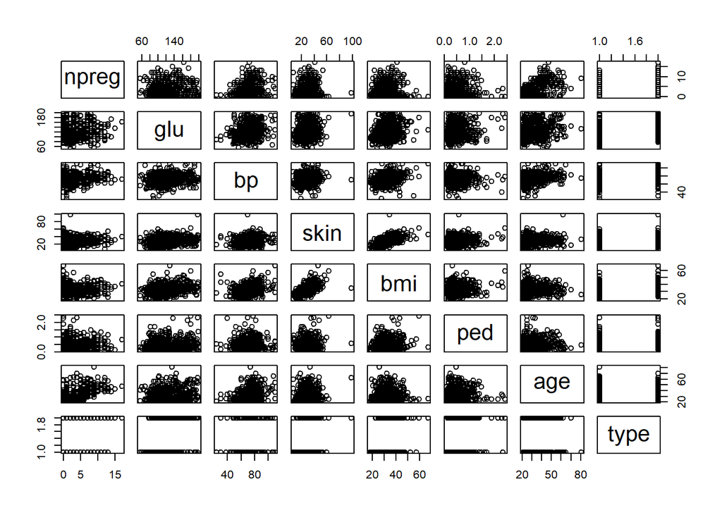

```r
loadPkg("psych")
pairs(pima)
```

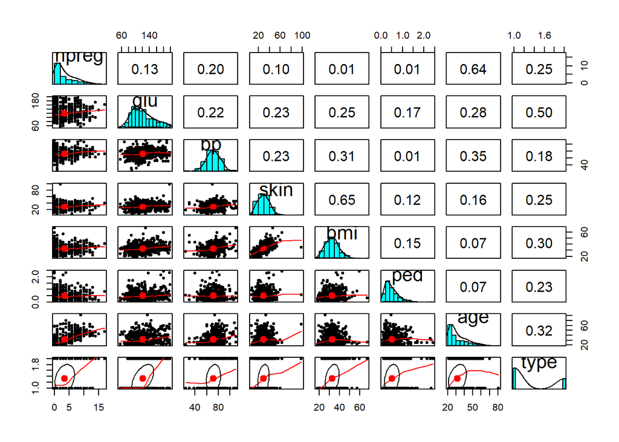

```r
pairs.panels(pima)
```

```r
unloadPkg("psych")
```

There is high correlation (.5 or greater) between `glu` and `type`, `skin` and `bmi`, and `age` and `npreg`. Other than that, some of the spreads seem to have a pattern no matter what they’re plotted against. `glu` doesn’t seem to have significant correlation with anything other than type, and skin/bmi have a clump of observations.

## KNN

### Question 4

**Train-Test split 3:1**  
First, standardize all of the X variables (i.e. all by `type`). Now, in order to perform KNN analysis, we need to separate the X variables and the y variable `type`. Before we separate them out, create a vector/array of 1s and 2s to create a train-test split in the ratio of 3:1 (i.e. 75% training, 25% test). Make sure to set a constant seed value (e.g. using `set.seed`) so that you can duplicate the results. You should end up with a dataframe of Xs for training with the corresponding vector of y, and a dataframe of Xs for testing with the corresponding vector of y. Make sure the order of observations in train-X and train-y are not mixed up during the process. Same for test-X and test-y.

```r
scaledpima <- as.data.frame(scale(pima[1:7], center = TRUE, scale = TRUE))
set.seed(2)
pima_sample <- sample(2, nrow(scaledpima), replace=TRUE, prob=c(0.75, 0.25))

pima_sample
```

```
##   [1] 1 1 1 1 2 2 1 2 1 1 1 1 2 1 1 2 2 1 1 1 1 1 2 1 1 1 1 1 2 1 1 1 2 2 1 1 2
##  [38] 1 1 1 2 1 1 1 2 2 2 1 1 2 1 1 1 2 1 2 2 2 1 1 2 2 1 1 2 1 1 1 1 1 1 1 1 1
##  [75] 1 2 1 2 1 1 1 1 1 1 1 2 2 1 1 1 2 1 1 1 1 1 1 1 1 1 1 1 2 2 1 1 2 1 1 1 1
## [112] 1 1 1 2 2 2 1 2 1 1 1 2 2 1 2 1 1 1 1 1 2 1 2 1 1 1 2 1 1 1 1 1 1 1 1 1 1
## [149] 1 1 1 1 2 1 2 1 2 1 1 1 2 2 1 2 1 1 1 2 1 1 2 1 1 2 1 2 1 1 1 1 2 1 2 2 1
## [186] 2 1 1 1 1 1 1 2 1 1 1 1 1 1 1 2 1 1 2 1 2 1 1 1 1 2 1 2 1 2 1 1 1 1 1 1 2
## [223] 1 1 1 2 2 1 1 2 1 1 2 1 2 1 1 1 1 1 2 1 1 2 2 2 1 1 1 1 1 1 1 1 1 1 1 1 1
## [260] 1 2 1 1 1 2 1 1 1 2 1 2 2 2 1 2 1 2 1 1 1 1 2 1 1 1 2 1 1 2 1 1 1 1 1 1 1
## [297] 1 1 1 1 2 1 1 2 2 1 1 1 2 1 1 1 2 1 1 1 1 1 1 1 1 1 1 1 1 1 1 1 1 1 1 2 2
## [334] 1 1 1 1 1 2 2 2 2 2 1 1 1 1 2 1 1 1 1 1 2 1 2 2 1 1 1 1 1 1 1 1 1 1 1 1 1
## [371] 2 1 1 1 1 1 1 2 1 1 1 1 1 1 1 1 1 1 2 2 2 2 1 1 1 1 1 2 1 2 1 1 1 1 2 2 1
## [408] 1 1 2 1 1 1 1 1 1 1 1 1 2 2 1 1 1 2 1 1 1 1 1 1 2 2 1 1 2 1 2 2 1 1 1 2 1
## [445] 1 1 2 1 1 1 1 1 1 1 2 2 1 2 2 1 2 1 1 1 1 2 1 1 1 1 1 1 1 1 1 2 1 1 1 2 1
## [482] 2 2 2 2 1 1 1 2 2 1 1 1 2 1 1 1 2 1 1 1 1 1 1 1 1 1 1 2 1 1 1 1 1 1 1 2 1
## [519] 1 2 2 1 1 1 1 1 1 1 1 2 1 2
```

```r
train_X <- scaledpima[pima_sample==1, 1:7]
test_X <- scaledpima[pima_sample==2, 1:7]
train_y <- pima[pima_sample==1, 8]
test_y <- pima[pima_sample==2, 8]
```

### Question 5

**KNN results**  
Perform the KNN analysis, with different k values. You do not need to show all the results from different k, but please include the one with the best (total) accuracy in your submission. How does the accuracy compared to the percentages of being T/F in the dataset?

```r
loadPkg("FNN")
loadPkg("gmodels")
loadPkg("caret")

ResultDf = data.frame(k= numeric(0), Total.Accuracy = numeric(0), row.names = NULL)

for (kval in 3:20) {
  pima_pred <- knn(train = train_X, test = test_X, cl=train_y, k=kval)
  pima_pred_cross <- CrossTable(test_y, pima_pred, prop.chisq = FALSE)
  print(paste("k = ", kval))

  cm = confusionMatrix(pima_pred, reference = test_y) # from caret library

  cmaccu = cm$overall['Accuracy']
  print(paste("Total Accuracy = ", cmaccu))

  cmt = data.frame(k=kval, Total.Accuracy = cmaccu, row.names = NULL)

  ResultDf = rbind(ResultDf, cmt)
  print(xkabledply(as.matrix(cm), title = paste("ConfusionMatrix for k = ", kval)))
  print(xkabledply(data.frame(cm$byClass), title = paste("k = ", kval)))
}
```

```r
loadPkg("FNN")
loadPkg("gmodels")
loadPkg("caret")
pima_pred <- knn(train = train_X, test = test_X, cl=train_y, k=20, prob = TRUE)
pima_pred_cross <- CrossTable(test_y, pima_pred, prop.chisq = FALSE)
```

```
##
##
##    Cell Contents
## |-------------------------|
## |                       N |
## |           N / Row Total |
## |           N / Col Total |
## |         N / Table Total |
## |-------------------------|
##
##
## Total Observations in Table:  142
##
##
##              | pima_pred
##       test_y |        No |       Yes | Row Total |
## -------------|-----------|-----------|-----------|
##           No |        96 |         3 |        99 |
##              |     0.970 |     0.030 |     0.697 |
##              |     0.821 |     0.120 |           |
##              |     0.676 |     0.021 |           |
## -------------|-----------|-----------|-----------|
##          Yes |        21 |        22 |        43 |
##              |     0.488 |     0.512 |     0.303 |
##              |     0.179 |     0.880 |           |
##              |     0.148 |     0.155 |           |
## -------------|-----------|-----------|-----------|
## Column Total |       117 |        25 |       142 |
##              |     0.824 |     0.176 |           |
## -------------|-----------|-----------|-----------|
##
##
```

```r
cm = confusionMatrix(pima_pred, reference = test_y)
cmaccu = cm$overall['Accuracy']
print(paste("Total Accuracy = ", cmaccu))
```

```
## [1] "Total Accuracy =  0.830985915492958"
```

```r
yes_count = sum(pima$type=='Yes')
no_count = sum(pima$type=='No')
no_count/(yes_count+no_count)
```

```
## [1] 0.667
```

```r
unloadPkg("caret")
unloadPkg("gmodels")
```

## Logistic Regression and comparison

### Question 6

**Logistic Regression results**  
Compare to the best logistic regression you can get. (Use the full model with all variables, since that is what we have for KNN.) How is the accuracy (assumes the standard cutoff of 0.5) compared to KNN?

```r
library(ModelMetrics)
library(pROC)
library(ResourceSelection)
library(pscl)
attach(pima)
pimaLogit <- glm(type ~ npreg + glu + bp + bmi + ped + age, family = "binomial")
summary(pimaLogit)
```

```
##
## Call:
## glm(formula = type ~ npreg + glu + bp + bmi + ped + age, family = "binomial")
##
## Deviance Residuals:
##    Min      1Q  Median      3Q     Max
## -3.000  -0.663  -0.371   0.637   2.493
##
## Coefficients:
##             Estimate Std. Error z value Pr(>|z|)
## (Intercept) -9.59082    0.99287   -9.66  < 2e-16 ***
## npreg        0.12350    0.04369    2.83  0.00470 **
## glu          0.03535    0.00424    8.34  < 2e-16 ***
## bp          -0.00761    0.01030   -0.74  0.46001
## bmi          0.08906    0.01883    4.73  2.2e-06 ***
## ped          1.31306    0.36382    3.61  0.00031 ***
## age          0.02672    0.01395    1.91  0.05555 .
## ---
## Signif. codes:  0 '***' 0.001 '**' 0.01 '*' 0.05 '.' 0.1 ' ' 1
##
## (Dispersion parameter for binomial family taken to be 1)
##
##     Null deviance: 676.79  on 531  degrees of freedom
## Residual deviance: 466.53  on 525  degrees of freedom
## AIC: 480.5
##
## Number of Fisher Scoring iterations: 5
```

```r
xkabledply(confusionMatrix(actual=pimaLogit$y, predicted=pimaLogit$fitted.values), title = "Confusion Matrix")
```

Confusion Matrix

| 1 | 2 |
| --- | --- |
| 318 | 73 |
| 37 | 104 |

```r
pimaNullLogit <- glm(type ~ 1, family = "binomial")
mcFadden = 1 - logLik(pimaLogit)/logLik(pimaNullLogit)
mcFadden
```

```
## 'log Lik.' 0.311 (df=7)
```

```r
pR2(pimaLogit)
```

```
## fitting null model for pseudo-r2
```

```
##      llh  llhNull       G2 McFadden     r2ML     r2CU
## -233.267 -338.394  210.254    0.311    0.326    0.454
```

The overall accuracy of the logistic regression, with all of the data as a the sample, is lower, at an accuracy of .793. Notably, however, the logistic regression has a much lower false negative rate, which could be important in this context.

### Question 7

**ROC-AUC**  
What is the AUC for the logit model? Plot the ROC. We should be able to compute the ROC and AUC for the KNN model the same way. Can you compare them?

```r
prob = predict(pimaLogit, type = "response")
pima$prob = prob
h <- roc(type~prob)
auc(h)
```

```
## Area under the curve: 0.861
```

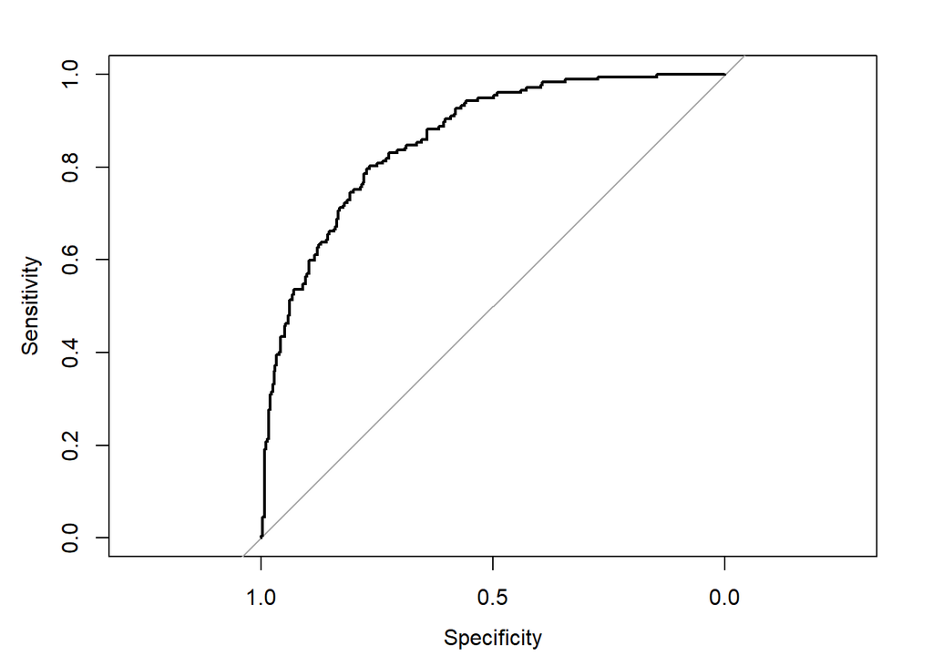

```r
plot(h)
```

```r
attributes(pima_pred)$prob
```

```
##   [1] 0.70 0.65 0.80 0.95 0.60 0.80 1.00 0.90 0.70 0.80 1.00 0.50 0.60 0.90 0.90
##  [16] 0.70 0.95 0.85 0.75 0.65 0.75 0.85 0.95 0.65 0.75 0.80 1.00 0.80 0.90 0.80
##  [31] 0.50 0.60 0.50 0.65 0.75 0.70 0.55 0.95 0.55 0.55 0.90 0.95 0.50 0.65 1.00
##  [46] 0.70 1.00 0.90 0.65 0.90 0.85 0.65 0.65 0.55 0.85 0.85 0.95 0.65 0.90 0.55
##  [61] 0.90 0.85 1.00 0.55 0.90 0.55 1.00 0.95 0.85 0.70 0.95 0.95 0.50 0.60 0.70
##  [76] 1.00 0.65 0.90 1.00 0.90 0.50 0.85 0.75 0.75 1.00 0.60 0.60 1.00 0.85 0.90
##  [91] 0.95 0.55 0.60 0.65 0.50 1.00 0.65 1.00 0.90 0.95 0.80 0.75 1.00 0.65 0.70
## [106] 0.55 0.95 0.75 0.65 0.95 0.85 0.95 0.50 0.75 0.90 0.65 0.50 0.80 0.75 0.90
## [121] 0.70 0.95 0.90 0.95 0.50 0.75 0.95 0.60 0.75 0.55 0.75 0.75 0.65 0.75 0.80
## [136] 0.90 1.00 0.55 0.65 1.00 0.75 0.60
```

```r
h <- roc(test_y~attributes(pima_pred)$prob)
auc(h)
```

```
## Area under the curve: 0.781
```

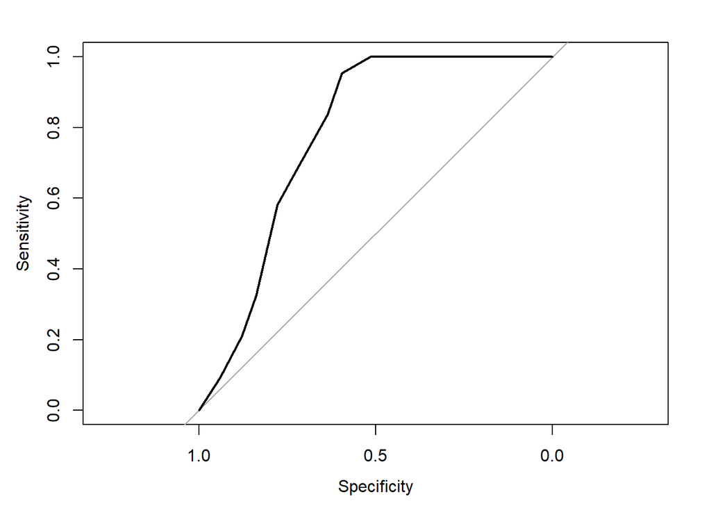

```r
plot(h)
```